# Data Science Skills

Jim Ng, Lewris Mota, Suma Gopal, Fernando Figueres

March 22, 2019

### Data Acquisition

#### Data loading

In this stage, the original dataframe will be loaded into the environment in order to start the cleaning process.

#### Original Dataset Display

Dimensions:

```
## [1] 5715   43
```

Display of the first 50 rows from the data.

| x | job_title | link | queried_salary | job_type | skill | no_of_skills | company | no_of_reviews | no_of_stars | date_since_posted | description | location | company_revenue | company_employees | company_industry | python | sql | machine.learning | r | hadoop | tableau | sas | spark | java | others | ca | ny | va | tx | … |
| --- | --- | --- | --- | --- | --- | --- | --- | --- | --- | --- | --- | --- | --- | --- | --- | --- | --- | --- | --- | --- | --- | --- | --- | --- | --- | --- | --- | --- | --- | --- |
| 0 | Data Scientist | https://www.indeed.com/rc/clk?jk=6a105f495c36afe3&fccid=281a27deb89bbe92&vjs=3 | <80000 | data_scientist | [‘SAP’, ‘SQL’] | 2 | Express Scripts | 3301 | 3.3 | 1 | [<p><b>POSITION SUMMARY</b></p>, <p> The Business Analyst role is the primary architect of reporting and dashboard solutions for internal and external clients. Utilizing ESI corporate standard develop… | MO | More than $10B (USD) | 10,000+ | Health Care | 0 | 1 | 0 | 0 | 0 | 0 | 0 | 0 | 0 | 1 | 0 | 0 | 0 | 0 | … |
| 1 | Data Scientist | https://www.indeed.com/rc/clk?jk=86afd561ea8c60bc&fccid=b584cf601069b5d0&vjs=3 | <80000 | data_scientist | [‘Machine Learning’, ‘R’, ‘SAS’, ‘SQL’, ‘Python’] | 5 | Money Mart Financial Services | NA | NA | 15 | [<p><b>What do we need?</b></p>, <ul><li> You to have an amazing personality and communication style.</li><li> That you are super-organized and are a problem solver.</li><li> That you take pride in ev… | TX |  |  |  | 1 | 1 | 1 | 1 | 0 | 0 | 1 | 0 | 0 | 0 | 0 | 0 | 0 | 1 | … |
| 2 | Data Scientist | https://www.indeed.com/rc/clk?jk=e0aad317e6d45d9b&fccid=b39fb6f124ce8586&vjs=3 | <80000 | data_scientist | [‘Data Mining’, ‘Data Management’, ‘R’, ‘SAS’, ‘SQL’, ‘STATA’, ‘SPSS’, ‘Data Analysis’, ‘Python’] | 9 | comScore | 62 | 3.5 | 1 | [<ul><li>Validate, analyze, and conduct statistical analysis on data using analytical software (Excel, SQL, and SAS).</li><li>Analyze and define efficient, workable solutions that support client busin… | OR |  |  |  | 1 | 1 | 0 | 1 | 0 | 0 | 1 | 0 | 0 | 1 | 0 | 0 | 0 | 0 | … |
| 3 | Graduate Studies Program - Data Scientist | https://www.indeed.com/rc/clk?jk=1cfdd9e391a6328a&fccid=e9870e3159e9c6ac&vjs=3 | <80000 | data_scientist | [‘Certified Internal Auditor’] | 1 | Central Intelligence Agency | 158 | 4.3 | 30 | [<p>Full time</p>, <p>Washington, DC metro area</p>, <p>Starting salary: $56,698 - $76,377 ($27.17 - $36.60 per hour) </p>, <p>US citizenship required (dual national US citizens are eligible)</p>, <p>… | DC |  |  | Government | 0 | 0 | 0 | 0 | 0 | 0 | 0 | 0 | 0 | 1 | 0 | 0 | 0 | 0 | … |
| 4 | Data Scientist I | https://www.indeed.com/rc/clk?jk=fec647775a21ecc6&fccid=2c6850e24c8a2811&vjs=3 | <80000 | data_scientist | [‘Statistical Software’, ‘Time Management’, ‘R’, ‘Microsoft Office’, ‘Excel’, ‘Tableau’, ‘Data Science’] | 7 | Federal Reserve Bank of Dallas | 495 | 4.1 | 30 | [<ul><li>Assist in consultations with business partners and internal/external HR functional experts to develop and maintain HR dashboards, models and metrics.</li><li>Research national best practices … | TX |  | Less than 10,000 | Banks and Financial Services | 0 | 0 | 0 | 1 | 0 | 1 | 0 | 0 | 0 | 1 | 0 | 0 | 0 | 1 | … |
| 5 | Data Scientist - Entry to Experienced Level | https://www.indeed.com/rc/clk?jk=835a2db493898f25&fccid=e8f18ca6180ec8da&vjs=3 | <80000 | data_scientist | [‘AI’, ‘Quantitative Analysis’, ‘Data Mining’, ‘Machine Learning’, ‘Analysis Skills’, ‘CSS’] | 6 | National Security Agency | 173 | 4.3 | 30 | [<ul><li>Collecting and combining data from multiple sources</li><li>Uncovering and exploring anomalous data (including metadata)</li><li>Applying the scientific process to data evaluation, performing… | MD |  |  |  | 0 | 0 | 1 | 0 | 0 | 0 | 0 | 0 | 0 | 1 | 0 | 0 | 0 | 0 | … |
| 6 | Geospatial Data Scientist | https://www.indeed.com/rc/clk?jk=6255c4e94a7efa27&fccid=4500f579ddd13a3b&vjs=3 | <80000 | data_scientist | [‘Statistical Software’, ‘Machine Learning’, ‘R’, ‘Image Processing’, ‘SQL’, ‘Cloud Computing’, ‘ArcGIS’, ‘GIS’, ‘Python’, ‘AWS’] | 10 | NYC Careers | 30 | 3.8 | 5 |  | NY |  |  | Government | 1 | 1 | 1 | 1 | 0 | 0 | 0 | 0 | 0 | 1 | 0 | 1 | 0 | 0 | … |
| 7 | Data Scientist | https://www.indeed.com/rc/clk?jk=f30ab3f52226b156&fccid=291c4b8251ea1163&vjs=3 | <80000 | data_scientist | [‘Machine Learning’, ‘R’, ‘SQL’] | 3 | OM Partners | NA | NA | 10 | [<p>With demand sensing, OM Partners is breaking through some boundaries of classical demand forecasting. The use of state of the art techniques like machine learning and neural networks allow for a s… | GA |  |  |  | 0 | 1 | 1 | 1 | 0 | 0 | 0 | 0 | 0 | 0 | 0 | 0 | 0 | 0 | … |
| 8 | Bioinformatics Data Scientist | https://www.indeed.com/rc/clk?jk=a6e45b6264f26b10&fccid=95ffa1338c01d3de&vjs=3 | <80000 | data_scientist | [‘Linux’, ‘R’, ‘C/C++’, ‘Python’] | 4 | University of Idaho | 233 | 4.2 | 1 | [<ul><li>Masters degree in Bioinformatics or three years’ experience and advanced degree in Computer Science, Statistics, Biology, or related discipline.</li><li>Experience with computer languages c… | ID |  |  | Education and Schools | 1 | 0 | 0 | 1 | 0 | 0 | 0 | 0 | 0 | 1 | 0 | 0 | 0 | 0 | … |
| 9 | Data Scientist | https://www.indeed.com/rc/clk?jk=56090c965b57d1c4&fccid=ca509b164585637a&vjs=3 | <80000 | data_scientist | [‘JavaScript’, ‘Data Mining’, ‘TS/SCI Clearance’, ‘R’, ‘C/C++’, ‘Python’] | 6 | usajobs.gov | 4227 | 4.3 | 22 | [<ul><div><h2 class=“jobSectionHeader”><b>Duties </b></h2><h3 class=“jobSectionHeader”><b>Summary </b></h3><div><br/> <p>JOB DESCRIPTION: Data Scientists develop and apply methods to identify, collect… | MO |  | 10,000+ | Government | 1 | 0 | 0 | 1 | 0 | 0 | 0 | 0 | 0 | 1 | 0 | 0 | 0 | 0 | … |
| 10 | Data Scientist | https://www.indeed.com/rc/clk?jk=8c8963cb38cd4907&fccid=1f92178814b05d89&vjs=3 | <80000 | data_scientist | [‘Machine Learning’, ‘R’, ‘SPSS’, ‘Data Analysis’, ‘Statistical Software’, ‘Data Mining’, ‘SAS’, ‘Python’] | 8 | The University of Pittsburgh | 541 | 4.2 | 1 | [<p>The Department of Epidemiology at the University of Pittsburgh’s Graduate School of Public Health is seeking a qualified Data Scientist.</p>, <p> The Data Scientist will work to improve existing… | PA |  |  | Education and Schools | 1 | 0 | 1 | 1 | 0 | 0 | 1 | 0 | 0 | 1 | 0 | 0 | 0 | 0 | … |
| 11 | Data Scientist | https://www.indeed.com/rc/clk?jk=dffcee22fbc2647a&fccid=1f92178814b05d89&vjs=3 | <80000 | data_scientist | [‘Machine Learning’, ‘R’, ‘SPSS’, ‘Data Analysis’, ‘Statistical Software’, ‘Data Mining’, ‘SAS’, ‘Python’] | 8 | The University of Pittsburgh | 541 | 4.2 | 1 | [<p>The Department of Epidemiology at the University of Pittsburgh’s Graduate School of Public Health is seeking a qualified Data Scientist.</p>, <p> The Data Scientist will work to improve existing… | PA |  |  | Education and Schools | 1 | 0 | 1 | 1 | 0 | 0 | 1 | 0 | 0 | 1 | 0 | 0 | 0 | 0 | … |
| 12 | Data Scientist | https://www.indeed.com/rc/clk?jk=290bda935f2dacf6&fccid=a3d79a6d43cd3473&vjs=3 | <80000 | data_scientist | [‘Machine Learning’, ‘Analysis Skills’, ‘Data Science’] | 3 | Rice University | 150 | 4.3 | 30 | [<p>Salary Commensurate with Experience and Qualifications</p>, <p>Monday through Friday, 8 a.m. to 5 p.m.; some late evenings may be required including some weekends.</p>, <p>Texas Policy Lab (TPL) i… | TX | Less than $1B (USD) | Less than 10,000 | Education and Schools | 0 | 0 | 1 | 0 | 0 | 0 | 0 | 0 | 0 | 1 | 0 | 0 | 0 | 1 | … |
| 13 | Jr. Data Scientist - Machine Learning | https://www.indeed.com/rc/clk?jk=8c2855de0feec361&fccid=918f9b74accbe201&vjs=3 | <80000 | data_scientist | [‘Machine Learning’, ‘Python’] | 2 | Elev8 Hire Solutions | NA | NA | 6 | [<p>Mid Data Scientist</p>, <p>Our client in the Midtown area is looking for a Jr. Data Scientist with a passion for Machine Learning, knows the how’s &amp; why’s of algorithms, and is excited about t… | GA |  |  |  | 1 | 0 | 1 | 0 | 0 | 0 | 0 | 0 | 0 | 0 | 0 | 0 | 0 | 0 | … |
| 14 | Data Scientist | https://www.indeed.com/rc/clk?jk=ba1b24901c04182c&fccid=7cb8926c790321ab&vjs=3 | <80000 | data_scientist | [‘TensorFlow’, ‘Project Planning’, ‘Linux’, ‘Machine Learning’, ‘C/C++’, ‘Python’, ‘Jira’] | 7 | Catalina Marketing | 81 | 3.2 | 30 | [<p><b>WHY CATALINA </b></p>, <p>Catalina’s personalized digital media connects shoppers to the brands we know they want. We do this by delivering only the most relevant ads and offers from their ho… | GA | Less than $1B (USD) | Less than 10,000 | Consulting and Business Services | 1 | 0 | 1 | 0 | 0 | 0 | 0 | 0 | 0 | 1 | 0 | 0 | 0 | 0 | … |
| 15 | Enrollment Data Scientist & Econometrician | https://www.indeed.com/rc/clk?jk=392a25a4538255e0&fccid=dc35d3f5eff3380a&vjs=3 | <80000 | data_scientist | [‘Machine Learning’, ‘R’, ‘Statisical Analysis’, ‘SPSS’, ‘Statistical Software’, ‘Data Mining’, ‘Scala’, ‘Tableau’, ‘Java’, ‘“Drivers License”’, ‘Python’] | 11 | Florida Polytechnic University | 16 | 3.9 | 1 | [<p>Located along Florida’s I-4 High Tech Corridor, Florida Poly opened its doors in August 2014 as the state’s 12th university and the only one dedicated to core subjects in Science, Technology, … | FL |  | Less than 10,000 | Education and Schools | 1 | 0 | 1 | 1 | 0 | 1 | 0 | 0 | 1 | 1 | 0 | 0 | 0 | 0 | … |
| 16 | Junior Data Scientist | https://www.indeed.com/rc/clk?jk=31ae275f05456ffc&fccid=1c0efdb7854b6585&vjs=3 | <80000 | data_scientist | [‘Machine Learning’, ‘R’, ‘SQL’, ‘Analysis Skills’, ‘Python’, ‘Data Science’] | 6 | Achievement Network (ANet) | NA | NA | 30 | [<p> Achievement Network (ANet) is a nonprofit dedicated to educational equity. We help schools boost student learning with great teaching that’s grounded in standards, informed by data, and built o… | MA |  |  |  | 1 | 1 | 1 | 1 | 0 | 0 | 0 | 0 | 0 | 1 | 0 | 0 | 0 | 0 | … |
| 17 | Data Scientist | https://www.indeed.com/rc/clk?jk=6be53db39253f014&fccid=9e215d88a6b33622&vjs=3 | <80000 | data_scientist | [‘Microsoft SQL Server’, ‘Data Mining’, ‘Machine Learning’, ‘Visual Basic’, ‘R’, ‘SAS’, ‘SQL’, ‘Excel’, ‘Tableau’, ‘Microsoft Access’, ‘SPSS’, ‘Python’] | 12 | Deloitte | 7197 | 4.0 | 30 | [<ul><li><div>Implement large-scale data ecosystems including data management, governance and the integration of structured and unstructured data to generate insights leveraging cloud-based platforms<… | VA |  | 10,000+ | Consulting and Business Services | 1 | 1 | 1 | 1 | 0 | 1 | 1 | 0 | 0 | 1 | 0 | 0 | 1 | 0 | … |
| 18 | Data Analytics and Machine Learning Specialist | https://www.indeed.com/rc/clk?jk=3a200a28f9041a04&fccid=1ddb91d85c72e885&vjs=3 | <80000 | data_scientist | [‘Machine Learning’] | 1 | ExxonMobil | 2234 | 4.0 | 11 | [<p>ExxonMobil Research and Engineering Company is seeking ambitious and motivated candidates with Engineering, Applied Math, Computer Science or related experience and with an interest in applying da… | NJ | More than $10B (USD) | 10,000+ | Energy and Utilities | 0 | 0 | 1 | 0 | 0 | 0 | 0 | 0 | 0 | 0 | 0 | 0 | 0 | 0 | … |
| 19 | Postdoctoral Associate/Data Scientist, Laboratory for Multis… | https://www.indeed.com/rc/clk?jk=2037d50ef865535f&fccid=71cf745ec1b3aae4&vjs=3 | <80000 | data_scientist | [‘LMRT’, ‘Machine Learning’] | 2 | MIT | 278 | 4.2 | 5 | [<p><b>Working at MIT offers opportunities, an environment, a culture – and benefits – that just aren’t found together anywhere else. If you’re curious, motivated, want to be part of a unique … | MA |  |  | Education and Schools | 0 | 0 | 1 | 0 | 0 | 0 | 0 | 0 | 0 | 1 | 0 | 0 | 0 | 0 | … |
| 20 | innovationOchsner (iO) - Data Scientist - Benson Tower | https://www.indeed.com/rc/clk?jk=1ab50cdc801e4dad&fccid=ef34ff29d760a6f2&vjs=3 | <80000 | data_scientist | [‘AI’, ‘Data Mining’, ‘Machine Learning’, ‘R’, ‘Natural Language Processing’, ‘Data Science’, ‘Python’] | 7 | Ochsner Health System | 1299 | 3.9 | 30 | [<p><b>We’ve made a lot of progress since opening the doors in 1942, but one thing has never changed - our commitment to serve, heal, lead, educate, </b><b>and innovate. We believe </b><b>that every a… | LA |  | 10,000+ | Health Care | 1 | 0 | 1 | 1 | 0 | 0 | 0 | 0 | 0 | 1 | 0 | 0 | 0 | 0 | … |
| 21 | Statistician/Data Scientist | https://www.indeed.com/rc/clk?jk=7ef6bcd4c1cb7dcd&fccid=aa53b551f9df0210&vjs=3 | <80000 | data_scientist | [‘IIS’, ‘TS/SCI Clearance’] | 2 | Raytheon | 3166 | 4.0 | 30 | [<p>Raytheon is an Equal Opportunity/Affirmative Action employer. All qualified applicants will receive consideration for employment without regard to race, color, religion, creed, sex, sexual orienta… | MO | More than $10B (USD) | 10,000+ | Aerospace and Defense | 0 | 0 | 0 | 0 | 0 | 0 | 0 | 0 | 0 | 1 | 0 | 0 | 0 | 0 | … |
| 22 | Statistician / Data Scientist | https://www.indeed.com/rc/clk?jk=e265edb0bb163a18&fccid=aa53b551f9df0210&vjs=3 | <80000 | data_scientist | [‘IIS’, ‘TS/SCI Clearance’] | 2 | Raytheon | 3166 | 4.0 | 30 | [<p>Raytheon is an Equal Opportunity/Affirmative Action employer. All qualified applicants will receive consideration for employment without regard to race, color, religion, creed, sex, sexual orienta… | MO | More than $10B (USD) | 10,000+ | Aerospace and Defense | 0 | 0 | 0 | 0 | 0 | 0 | 0 | 0 | 0 | 1 | 0 | 0 | 0 | 0 | … |
| 23 | Environmental Data Scientist, Bureau of Environmental Survei… | https://www.indeed.com/rc/clk?jk=36b066c2b1fcad50&fccid=4146d8487cdbf799&vjs=3 | <80000 | data_scientist | [‘Statistical Software’, ‘SAS’, ‘SQL’, ‘Tableau’] | 4 | NYC Careers | 265 | 4.1 | 30 |  | NY |  |  | Government | 0 | 1 | 0 | 0 | 0 | 1 | 1 | 0 | 0 | 1 | 0 | 1 | 0 | 0 | … |
| 24 | Environmental Data Manager/Data Scientist (Associate Level) | https://www.indeed.com/rc/clk?jk=15f179f4a2c91e25&fccid=3f0d5695925aa6ba&vjs=3 | <80000 | data_scientist | [‘Microsoft SQL Server’, ‘Data Management’, ‘Power BI’, ‘CAD Software’, ‘SQL’, ‘Microsoft Access’, ‘SharePoint’, ‘ArcGIS’] | 8 | ERM Group | 86 | 3.3 | 15 | [<p><b>ERM </b>is seeking an <b>Environmental Data Manager/Data Scientist </b>in the Southeastern United States. The ideal candidate will be self-motivated, detail-oriented, and interested in a career… | GA |  |  | Consulting and Business Services | 0 | 1 | 0 | 0 | 0 | 0 | 0 | 0 | 0 | 1 | 0 | 0 | 0 | 0 | … |
| 25 | Sr. Data Scientist - Secret | https://www.indeed.com/rc/clk?jk=9bad8e7ecfd34847&fccid=9e215d88a6b33622&vjs=3 | <80000 | data_scientist | [‘Data Mining’, ‘R’, ‘Python’] | 3 | Deloitte | 7197 | 4.0 | 30 | [<ul><li><div>Implement large-scale data ecosystems including data management, governance and the integration of structured and unstructured data to generate insights leveraging cloud-based platforms<… | VA |  | 10,000+ | Consulting and Business Services | 1 | 0 | 0 | 1 | 0 | 0 | 0 | 0 | 0 | 1 | 0 | 0 | 1 | 0 | … |
| 26 | innovation Ochsner - iO - Data Scientist - Benson Tower | https://www.indeed.com/rc/clk?jk=637c5cf376758bf0&fccid=ef34ff29d760a6f2&vjs=3 | <80000 | data_scientist | [‘AI’, ‘Data Mining’, ‘Machine Learning’, ‘R’, ‘Natural Language Processing’, ‘Data Science’, ‘Python’] | 7 | Ochsner Health System | 1299 | 3.9 | 30 | [<p><b>We’ve made a lot of progress since opening the doors in 1942, but one thing has never changed - our commitment to serve, heal, lead, educate, </b><b>and innovate. We believe </b><b>that every a… | LA |  | 10,000+ | Health Care | 1 | 0 | 1 | 1 | 0 | 0 | 0 | 0 | 0 | 1 | 0 | 0 | 0 | 0 | … |
| 27 | Google AI Resident, 2019 Start (Fixed-Term Employee) | https://www.indeed.com/rc/clk?jk=2ddc548ea3f366de&fccid=a5b4499d9e91a5c6&vjs=3 | <80000 | data_scientist |  | 0 | Google | 2641 | 4.3 | 21 | [<ul><li> We are accepting applications until January 28, 2019.</li><li> Our team will review applications on a rolling basis and interviews will begin in November 2018. It is in your best interest to… | NY | More than $10B (USD) | 10,000+ | Internet and Software | 0 | 0 | 0 | 0 | 0 | 0 | 0 | 0 | 0 | 0 | 0 | 1 | 0 | 0 | … |
| 28 | Google AI Resident, 2019 Start (Fixed-Term Employee) | https://www.indeed.com/rc/clk?jk=d5ad56e19ff35459&fccid=a5b4499d9e91a5c6&vjs=3 | <80000 | data_scientist |  | 0 | Google | 2641 | 4.3 | 21 | [<ul><li> We are accepting applications until January 28, 2019.</li><li> Our team will review applications on a rolling basis and interviews will begin in November 2018. It is in your best interest to… | MA | More than $10B (USD) | 10,000+ | Internet and Software | 0 | 0 | 0 | 0 | 0 | 0 | 0 | 0 | 0 | 0 | 0 | 0 | 0 | 0 | … |
| 29 | Data Analysis & Machine Learning Postdoctoral Researcher | https://www.indeed.com/rc/clk?jk=fbe8ba212a66f66c&fccid=26727f1861532c63&vjs=3 | <80000 | data_scientist | [‘TensorFlow’, ‘Machine Learning’, ‘Git’, ‘Python’, ‘SVN’] | 5 | Lawrence Livermore National Laboratory | 111 | 4.3 | 2 | [<p><b><i>Science and Technology on a Mission!</i></b></p>, <p> For more than 60 years, the Lawrence Livermore National Laboratory (LLNL) has applied science and technology to make the world a safer p… | CA | $1B to $5B (USD) | Less than 10,000 | Government | 1 | 0 | 1 | 0 | 0 | 0 | 0 | 0 | 0 | 1 | 1 | 0 | 0 | 0 | … |
| 30 | Applied Machine Learning Scientist - Digital Imaging | https://www.indeed.com/rc/clk?jk=25c78fd15a1225c6&fccid=f89deb5a97c7738a&vjs=3 | <80000 | data_scientist | [‘TensorFlow’, ‘JavaScript’, ‘React’, ‘Data Mining’, ‘Adobe Photoshop’, ‘Machine Learning’, ‘CSS’, ‘HTML5’] | 8 | Adobe | 484 | 4.3 | 30 | [<p>Adobe Photoshop is used by over 90% of the world’s creative professionals to bring what they imagine to life. Join our team – a startup inside Adobe – as we reimagine it to create a next gen… | CA | $5B to $10B (USD) | 10,000+ | Internet and Software | 0 | 0 | 1 | 0 | 0 | 0 | 0 | 0 | 0 | 1 | 1 | 0 | 0 | 0 | … |
| 31 | Machine Learning Scientist | https://www.indeed.com/rc/clk?jk=a4ad7885c2d9e171&fccid=485155ca34f4e0c7&vjs=3 | <80000 | data_scientist | [‘TensorFlow’, ‘Machine Learning’, ‘R’, ‘Python’, ‘C/C++’, ‘SQL’] | 6 | Intuitive Surgical | 95 | 3.8 | 30 | [<p><b>Company Description:</b></p>, <p> Who is Intuitive Surgical? The numbers tell an amazing story. Learn more about our company.</p>, <ul><li>Exploration and development of machine learning algori… | GA |  |  |  | 1 | 1 | 1 | 1 | 0 | 0 | 0 | 0 | 0 | 1 | 0 | 0 | 0 | 0 | … |
| 32 | Google AI Resident, 2019 Start (Fixed-Term Employee) | https://www.indeed.com/rc/clk?jk=83bb741f685c3d95&fccid=a5b4499d9e91a5c6&vjs=3 | <80000 | data_scientist |  | 0 | Google | 2641 | 4.3 | 21 | [<ul><li> We are accepting applications until January 28, 2019.</li><li> Our team will review applications on a rolling basis and interviews will begin in November 2018. It is in your best interest to… | CA | More than $10B (USD) | 10,000+ | Internet and Software | 0 | 0 | 0 | 0 | 0 | 0 | 0 | 0 | 0 | 0 | 1 | 0 | 0 | 0 | … |
| 33 | Data Scientist/Sr. Scientific Programmer (Researcher 6) | https://www.indeed.com/rc/clk?jk=5fe3136ede9ececa&fccid=5c42f0ed4ae5b712&vjs=3 | <80000 | data_scientist | [‘Machine Learning’, ‘Scripting’, ‘R’, ‘Perl’, ‘SQL’, ‘MATLAB’, ‘Python’] | 7 | University of Minnesota | 930 | 4.2 | 30 |  | MN |  |  | Education and Schools | 1 | 1 | 1 | 1 | 0 | 0 | 0 | 0 | 0 | 1 | 0 | 0 | 0 | 0 | … |
| 34 | Google AI Resident, 2019 Start (Fixed-Term Employee) | https://www.indeed.com/rc/clk?jk=db37806307dade6d&fccid=a5b4499d9e91a5c6&vjs=3 | <80000 | data_scientist |  | 0 | Google | 2641 | 4.3 | 21 | [<ul><li> We are accepting applications until January 28, 2019.</li><li> Our team will review applications on a rolling basis and interviews will begin in November 2018. It is in your best interest to… | WA | More than $10B (USD) | 10,000+ | Internet and Software | 0 | 0 | 0 | 0 | 0 | 0 | 0 | 0 | 0 | 0 | 0 | 0 | 0 | 0 | … |
| 35 | Machine Learning Intern (Summer 2019) | https://www.indeed.com/rc/clk?jk=e84451fb3b44e7af&fccid=aef928e89977f7f0&vjs=3 | <80000 | data_scientist | [‘Splunk’, ‘Data Mining’, ‘Machine Learning’, ‘Data Science’] | 4 | Splunk | 30 | 4.3 | 30 | [<p>Join us as we pursue our disruptive new vision to make machine data accessible, usable and valuable to everyone. We are a company filled with people who are passionate about our product and seek t… | CA |  | Less than 10,000 | Internet and Software | 0 | 0 | 1 | 0 | 0 | 0 | 0 | 0 | 0 | 1 | 1 | 0 | 0 | 0 | … |
| 36 | Data Scientist (Research Director) | https://www.indeed.com/rc/clk?jk=b39eca7b4aae31b0&fccid=5793e68a003f2fb6&vjs=3 | <80000 | data_scientist | [‘Grant Writing’] | 1 | Southern Methodist University | 126 | 4.2 | 30 | [<ul><li><div>Design, implement, and support the Deason Center’s research agenda. Identify critical areas of opportunity for innovative criminal justice research that align with the Deason Center’s fo… | TX |  |  | Education and Schools | 0 | 0 | 0 | 0 | 0 | 0 | 0 | 0 | 0 | 1 | 0 | 0 | 0 | 1 | … |
| 37 | Machine Learning Scientist II | https://www.indeed.com/rc/clk?jk=b0b692b299eeeac4&fccid=734cb5a01ee60f80&vjs=3 | <80000 | data_scientist | [‘Natural Language Processing’, ‘Hive’, ‘Spark’, ‘Microsoft Powerpoint’, ‘Machine Learning’, ‘Hadoop’, ‘MATLAB’, ‘Python’] | 8 | Microsoft | 5178 | 4.2 | 5 | [<ul><li>2+ years of experience building practical machine learning models with applications to real-world problems.</li><li>Experience with ML tools to build models and analyze data. (e.g. r, Python,… | WA | More than $10B (USD) | 10,000+ | Internet and Software | 1 | 0 | 1 | 0 | 1 | 0 | 0 | 1 | 0 | 1 | 0 | 0 | 0 | 0 | … |
| 38 | DATA SCIENTIST AND TEAM LEAD (Data Analytics Practice) | https://www.indeed.com/rc/clk?jk=0da5984107651519&fccid=686538d3cb10c608&vjs=3 | <80000 | data_scientist | [‘Data Mining’, ‘Statisical Analysis’, ‘Qualitative Research’] | 3 | Duke University and Duke University Health System | 191 | 4.0 | 16 | [<ul><li> Help OIT leadership build and manage the core data analytics team, including involvement in hiring, training, mentoring, and fostering talent development.</li><li> Help triage among competin… | NC |  |  | Health Care | 0 | 0 | 0 | 0 | 0 | 0 | 0 | 0 | 0 | 1 | 0 | 0 | 0 | 0 | … |
| 39 | DATA SCIENTIST, PROSPECT RESEARCH, MGMT & ANALYTICS-UNIV DEV… | https://www.indeed.com/rc/clk?jk=8efd80c5f5327d01&fccid=686538d3cb10c608&vjs=3 | <80000 | data_scientist | [‘Java’, ‘R’, ‘SAS’, ‘Python’, ‘SQL’, ‘Tableau’] | 6 | Duke University and Duke University Health System | 191 | 4.0 | 16 | [<p><b>Education</b> </p>, <p><b>Experience</b> </p>] | NC |  |  | Health Care | 1 | 1 | 0 | 1 | 0 | 1 | 1 | 0 | 1 | 0 | 0 | 0 | 0 | 0 | … |
| 40 | Senior Data Scientist, Supply Chain | https://www.indeed.com/rc/clk?jk=3e8093be990019de&fccid=a74a0fbbfa36acbd&vjs=3 | <80000 | data_scientist | [‘AI’, ‘Quantitative Analysis’, ‘Microsoft SQL Server’, ‘Machine Learning’, ‘Visual Basic’, ‘R’, ‘SQL’, ‘.Net’, ‘C#’, ‘Python’] | 10 | Coyote Logistics | 165 | 3.6 | 30 | [<p><b>Senior Data Scientist, Supply Chain </b></p>, <p>We are seeking an experienced Senior Data Science professional with a passion to derive value from data and insatiable curiosity to learn and tr… | IL |  | Less than 10,000 | Transport and Freight | 1 | 1 | 1 | 1 | 0 | 0 | 0 | 0 | 0 | 1 | 0 | 0 | 0 | 0 | … |
| 41 | Machine Learning | https://www.indeed.com/rc/clk?jk=33f4f5ff144200dd&fccid=7a3824693ee1074b&vjs=3 | <80000 | data_scientist | [‘Big Data’, ‘Natural Language Processing’, ‘Spark’, ‘Machine Learning’, ‘Hadoop’] | 5 | Twitter | 63 | 3.9 | 30 | [<p><b>What You’ll Do:</b></p>, <p>You will work with our team of experts in machine learning and software engineering to build powerful and scalable models and surface the most relevant content on … | CA | $1B to $5B (USD) | Less than 10,000 | Internet and Software | 0 | 0 | 1 | 0 | 1 | 0 | 0 | 1 | 0 | 1 | 1 | 0 | 0 | 0 | … |
| 42 | Temporary Content Developer - Machine Learning | https://www.indeed.com/rc/clk?jk=d693f99164a0652c&fccid=e10c55d179cada25&vjs=3 | <80000 | data_scientist | [‘TensorFlow’, ‘Machine Learning’, ‘Python’] | 3 | iD Tech | 39 | 4.5 | 1 | [<p>Description</p>, <p><b>The Position</b></p>, <p> iD Tech is looking for a Temporary Machine Learning Content Developer to produce the educational content and classroom tools to be used by our mach… | CA |  |  |  | 1 | 0 | 1 | 0 | 0 | 0 | 0 | 0 | 0 | 1 | 1 | 0 | 0 | 0 | … |
| 43 | Machine Learning | https://www.indeed.com/rc/clk?jk=4cfe1424f1f243e7&fccid=7a3824693ee1074b&vjs=3 | <80000 | data_scientist | [‘Big Data’, ‘Natural Language Processing’, ‘Spark’, ‘Machine Learning’, ‘Hadoop’] | 5 | Twitter | 63 | 3.9 | 30 | [<p><b>Who We Are:</b></p>, <p> Machine learning is advancing products at Twitter (e.g., Timeline ranking, On-boarding) and Cortex is advancing Machine learning at Twitter. Cortex is the central ML/AI… | NY | $1B to $5B (USD) | Less than 10,000 | Internet and Software | 0 | 0 | 1 | 0 | 1 | 0 | 0 | 1 | 0 | 1 | 0 | 1 | 0 | 0 | … |
| 44 | Computer Vision Scientist (Machine Learning) | https://www.indeed.com/rc/clk?jk=2b684de7cdc40a2d&fccid=91531f080b85f54c&vjs=3 | <80000 | data_scientist | [‘TensorFlow’, ‘Machine Learning’, ‘Image Processing’, ‘C/C++’] | 4 | Canvas Technology | NA | NA | 30 | [<ul> <li>Proven experience in computer vision and deep learning.</li> <li>Strong mathematics skills.</li> <li>Familiarity with DL frameworks (caffe, tensorflow, torch, keras)</li> <li>C++ programming… | CO |  |  |  | 0 | 0 | 1 | 0 | 0 | 0 | 0 | 0 | 0 | 1 | 0 | 0 | 0 | 0 | … |
| 45 | FamilySearch Machine Learning Annotation Specialist | https://www.indeed.com/rc/clk?jk=72521a99687d16f4&fccid=7e408d96768a4a43&vjs=3 | <80000 | data_scientist | [‘Machine Learning’, ‘Microsoft Powerpoint’, ‘Microsoft Office’] | 3 | The Church of Jesus Christ of Latter-day Saints | 1324 | 4.8 | 1 | [<p>Posting Dates: 10/06/2018 - 11/02/2018 </p>, <p>Job Family: Information Technology </p>, <p>Department: Family History Department </p>, <p><b>PURPOSES</b></p>, <p><b> RESPONSIBILITIES</b></p>, <p>… | UT |  | 10,000+ | Organization | 0 | 0 | 1 | 0 | 0 | 0 | 0 | 0 | 0 | 1 | 0 | 0 | 0 | 0 | … |
| 46 | Machine Learning Research Scientist - Optics & Photonics Lab | https://www.indeed.com/rc/clk?jk=779d3c6cf2ba01bf&fccid=d81796328c01c258&vjs=3 | <80000 | data_scientist | [‘.Net’, ‘C#’, ‘Machine Learning’, ‘Software Development’, ‘MATLAB’, ‘Image Processing’, ‘Signal Processing’, ‘Python’, ‘C/C++’] | 9 | Riverside Research | 15 | 3.7 | 30 |  | OH | Less than $1B (USD) | Less than 10,000 | Aerospace and Defense | 1 | 0 | 1 | 0 | 0 | 0 | 0 | 0 | 0 | 1 | 0 | 0 | 0 | 0 | … |
| 47 | Machine Learning Researcher SAN FRANCISCOMEMBER OF TECHNICAL… | https://www.indeed.com/rc/clk?jk=9bef042c0a49c9ec&fccid=c037aeb6086309d9&vjs=3 | <80000 | data_scientist | [‘AI’, ‘Machine Learning’] | 2 | OpenAI | NA | NA | 18 | [<ul><li>Track record of coming up with new ideas in machine learning, as demonstrated by one or more first author publications or projects</li><li>Past experience in creating high-performance impleme… | CA |  |  |  | 0 | 0 | 1 | 0 | 0 | 0 | 0 | 0 | 0 | 1 | 1 | 0 | 0 | 0 | … |
| 48 | Entry-Level Data Scientist | https://www.indeed.com/rc/clk?jk=75cfae0095c2b2a6&fccid=de71a49b535e21cb&vjs=3 | 80000-99999 | data_scientist | [‘Java’, ‘Data Mining’, ‘Machine Learning’, ‘Design Experience’, ‘Scripting’, ‘R’, ‘SAS’, ‘Python’] | 8 | IBM | 23472 | 3.9 | 1 | [<ul><li>You will implement and validate predictive models, and create and maintain statistical models with a focus on big data.</li><li>You’ll communicate with internal and external clients to unde… | USA |  | 10,000+ | Consulting and Business Services | 1 | 0 | 1 | 1 | 0 | 0 | 1 | 0 | 1 | 1 | 0 | 0 | 0 | 0 | … |
| 49 | Trainee as Data Scientist (January to June 2019) | https://www.indeed.com/rc/clk?jk=053c823c0f398c55&fccid=0196d12881dbeaab&vjs=3 | 80000-99999 | data_scientist | [‘Pentaho’, ‘Excel’] | 2 | Asendia Management SAS | NA | NA | 5 | [<ul><li>Contribute to the development of the data model for the Business Intelligence tool in collaboration with the key users, the subsidiaries and the IT partner.</li><li> Support the data team in … | OR |  |  |  | 0 | 0 | 0 | 0 | 0 | 0 | 0 | 0 | 0 | 1 | 0 | 0 | 0 | 0 | … |

### Transformations

```
## [1] 5617 2248
```

```
##
##    1   99
## 5616    1
```

### Data Normalization

we are going to create a simple star schema for this data set we need four tables, i.e. “job_post_specific”, “job_position”, “company”, & “description”. “job_post_specific” table - “jk_id” is the primary key. Each “jk_id” is unique and that represents a post for one job position from a company.

“job_position” table - beware of the original “fcc_id”! Note, the “job_post_specific” and “job_position” tables are different. The same job position is supposed to share an idential and unique “fcc_id”; however, there can be multiple posting. In other words, we expect to see the same “fcc_id” for multiple “jk_id”. For instance, Google posted four identical position “Google AI Resident, 2019 Start (Fixed-Term Employee)” with the same “fcc_id” (a5b4499d9e91a5c6) but four different “jk_id”. These four positions were offered in different locations (NY, MA, CA, & WA)

We should consider these four positions as one when counting for skill sets; otherwise, we will inflate our numbers when calculating for the percentage based on skill sets; however, the data is also messy in terms of some companies posted different job positions with the same “fcc_id”! Using Google and the same “fcc_id” (a5b4499d9e91a5c6) as an example, there are actually 40 entries in the data set that share the same “fcc_id”! That simply means that there are different job positions share the same “fcc_id”, but we also have identical jobs share the same “fcc_id” with different entries in the data set because they can be offered in different locations one extreme case, Booz Allen Hamilton posted 151 different jobs with identical “fcc_id” (4e041af1d0af1bc8)! We must clean up the messy “fcc_id” before splitting up the data set into four tables:

We must 1) remove duplication of identical jobs (job_title, queried_salary, job_type, skill, company), and 2) create unique “fcc_unique_id” as the primary key. Last but not least, we also need to clean up the “company” table by creating a company Id and performing simple Change-Data-Capture

#### Job Post Specific

|  | location | n |
| --- | --- | --- |
| 1 |  | 252 |
| 2 | AL | 17 |
| 3 | AR | 28 |
| 4 | AZ | 53 |
| 5 | CA | 1395 |
| 6 | CO | 109 |
| 7 | CT | 75 |
| 8 | DC | 140 |
| 9 | DE | 17 |
| 10 | FL | 103 |

[output cut: 42 more lines]

#### Job Postion

| fcc_unique_id | job_title | queried_salary | job_type | skill | company_id |
| --- | --- | --- | --- | --- | --- |
| 1_281a27deb89bbe92 | Data Scientist | <80000 | data_scientist | [‘SAP’, ‘SQL’] | c_761 |
| 2_b584cf601069b5d0 | Data Scientist | <80000 | data_scientist | [‘Machine Learning’, ‘R’, ‘SAS’, ‘SQL’, ‘Python’] | c_1336 |
| 3_b39fb6f124ce8586 | Data Scientist | <80000 | data_scientist | [‘Data Mining’, ‘Data Management’, ‘R’, ‘SAS’, ‘SQL’, ‘STATA’, ‘SPSS’, ‘Data Analysis’, ‘Python’] | c_523 |
| 4_e9870e3159e9c6ac | Graduate Studies Program - Data Scientist | <80000 | data_scientist | [‘Certified Internal Auditor’] | c_418 |
| 5_2c6850e24c8a2811 | Data Scientist I | <80000 | data_scientist | [‘Statistical Software’, ‘Time Management’, ‘R’, ‘Microsoft Office’, ‘Excel’, ‘Tableau’, ‘Data Science’] | c_782 |
| 6_e8f18ca6180ec8da | Data Scientist - Entry to Experienced Level | <80000 | data_scientist | [‘AI’, ‘Quantitative Analysis’, ‘Data Mining’, ‘Machine Learning’, ‘Analysis Skills’, ‘CSS’] | c_1374 |

#### Job Post

| jk_id | fcc_unique_id | link | date_since_posted | location |
| --- | --- | --- | --- | --- |
| 6a105f495c36afe3 | 1_281a27deb89bbe92 | https://www.indeed.com/rc/clk?jk=6a105f495c36afe3&fccid=281a27deb89bbe92&vjs=3 | 1 | MO |
| 86afd561ea8c60bc | 2_b584cf601069b5d0 | https://www.indeed.com/rc/clk?jk=86afd561ea8c60bc&fccid=b584cf601069b5d0&vjs=3 | 15 | TX |
| e0aad317e6d45d9b | 3_b39fb6f124ce8586 | https://www.indeed.com/rc/clk?jk=e0aad317e6d45d9b&fccid=b39fb6f124ce8586&vjs=3 | 1 | OR |
| 1cfdd9e391a6328a | 4_e9870e3159e9c6ac | https://www.indeed.com/rc/clk?jk=1cfdd9e391a6328a&fccid=e9870e3159e9c6ac&vjs=3 | 30 | DC |
| fec647775a21ecc6 | 5_2c6850e24c8a2811 | https://www.indeed.com/rc/clk?jk=fec647775a21ecc6&fccid=2c6850e24c8a2811&vjs=3 | 30 | TX |
| 835a2db493898f25 | 6_e8f18ca6180ec8da | https://www.indeed.com/rc/clk?jk=835a2db493898f25&fccid=e8f18ca6180ec8da&vjs=3 | 30 | MD |

#### Company

| company_id | company | company_revenue | company_employees | company_industry | no_of_stars | no_of_reviews |
| --- | --- | --- | --- | --- | --- | --- |
| c_1 |  |  |  |  | 4.0 | 14988 |
| c_3 | 14 West |  |  |  | 3.5 | 2 |
| c_4 | 1st Solution USA |  |  |  | NA | NA |
| c_5 | 23andMe |  | Less than 10,000 | Health Care | 4.0 | 4 |
| c_6 | 2DA Analytics |  |  |  | NA | NA |
| c_7 | 2K Games |  |  |  | 3.7 | 22 |

#### Description

| link | description |
| --- | --- |
| https://www.indeed.com/rc/clk?jk=6a105f495c36afe3&fccid=281a27deb89bbe92&vjs=3 | [<p><b>POSITION SUMMARY</b></p>, <p> The Business Analyst role is the primary architect of reporting and dashboard solutions for internal and external clients. Utilizing ESI corporate standard develop… |
| https://www.indeed.com/rc/clk?jk=86afd561ea8c60bc&fccid=b584cf601069b5d0&vjs=3 | [<p><b>What do we need?</b></p>, <ul><li> You to have an amazing personality and communication style.</li><li> That you are super-organized and are a problem solver.</li><li> That you take pride in ev… |
| https://www.indeed.com/rc/clk?jk=e0aad317e6d45d9b&fccid=b39fb6f124ce8586&vjs=3 | [<ul><li>Validate, analyze, and conduct statistical analysis on data using analytical software (Excel, SQL, and SAS).</li><li>Analyze and define efficient, workable solutions that support client busin… |
| https://www.indeed.com/rc/clk?jk=1cfdd9e391a6328a&fccid=e9870e3159e9c6ac&vjs=3 | [<p>Full time</p>, <p>Washington, DC metro area</p>, <p>Starting salary: $56,698 - $76,377 ($27.17 - $36.60 per hour) </p>, <p>US citizenship required (dual national US citizens are eligible)</p>, <p>… |
| https://www.indeed.com/rc/clk?jk=fec647775a21ecc6&fccid=2c6850e24c8a2811&vjs=3 | [<ul><li>Assist in consultations with business partners and internal/external HR functional experts to develop and maintain HR dashboards, models and metrics.</li><li>Research national best practices … |
| https://www.indeed.com/rc/clk?jk=835a2db493898f25&fccid=e8f18ca6180ec8da&vjs=3 | [<ul><li>Collecting and combining data from multiple sources</li><li>Uncovering and exploring anomalous data (including metadata)</li><li>Applying the scientific process to data evaluation, performing… |

### Analysis

The chart below tallies the the skill count accross the entire data set. We see that Python is the language of choice followed by R and Java. For database related technologies, SQL is the clear choice due to it’s ubiquity followed by “big data” variants such as Hadoop and Spark.

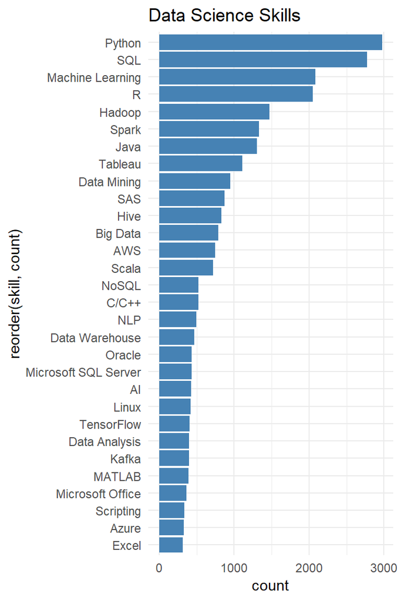

## Salary Index

As part of our analsys, we’ve calculated the relative value of each skill by dividing the expected salary of each position by the number of required skills. With this measure, we hoped to determine if some data scietist roles required less populat skills which command a higher salary.

Epected salary intervals were converted to a 1 to 6 scale with 6 corresponding to expected salries >$160000. This number was divided by the total number of skills and that weight is assigned to the skill. We later aggregated the mean and sums of this values as show in the charts below.

Our first chart plots the sum of the relative values and gives us a very similar result to the raw count scores from the above chart.

The next chart calculates the avegrage of relative values in this shows a very different picture. Less commong skills which are associated with higher paying jobs rise to the top. This chart is heavily influenced my skills with a low job count so the results need to be intepreted with caution. Rather than using it infer general trends, a candiate might find it useful to see if a skill he or she has might opne the door to a specialized role.

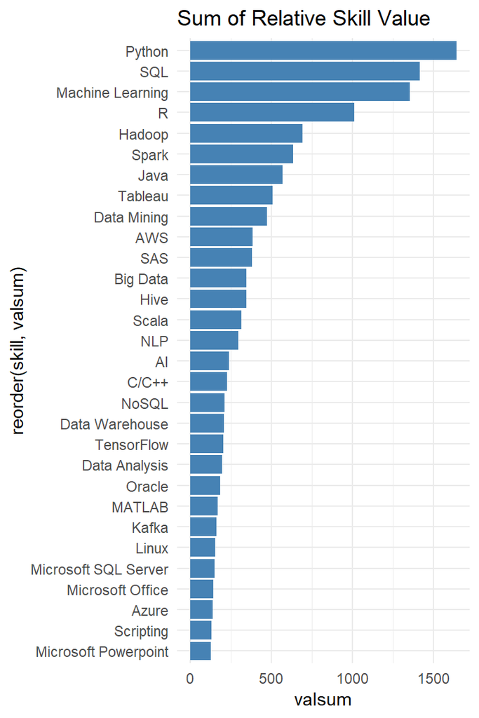

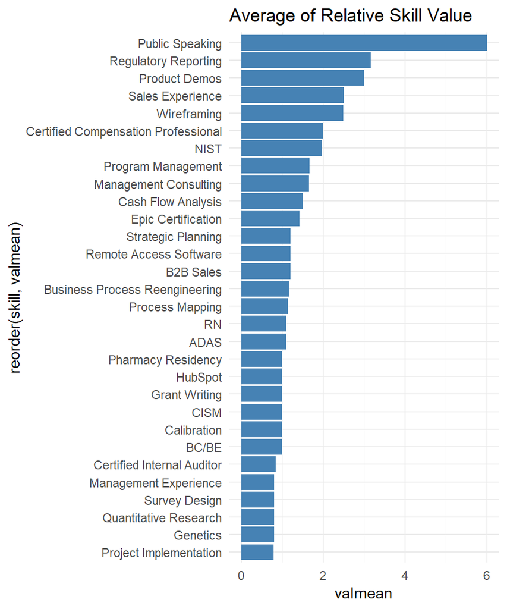

## Location

[figure not shown]